# GEOG 3155/6155 Lab 02 Spatial data in R Part 1

Alexander Hohl School of Environment, Society & Sustainability University of Utah

02 September, 2026

In this lab, we will explore some of R’s functionality with spatial data, with special attention given to the **sf** package. For more information about `sf`, you can visit their [website](https://r-spatial.github.io/sf/). Robin Lovelace’s book *Geocomputation with R* (available [online](https://geocompr.robinlovelace.net/)) is also a really helpful and educational source for learning **sf**. For some of the longer examples, it is highly recommended to use R’s scripting functions to run the examples to save on re-typing.

Next download the following files from the Google drive and move them to your `data` folder:

- Climate dataset for Western North America: *WNAclimate.csv*
- A shapefile of UTA light rail routes: *LightRail_UTA.shp*
- A shapefile of UTA light rail stations: *LightRailStations_UTA.shp*
- A shapefile of Utah counties: *utahcounty.shp*

Note for the shapefiles, you will need to download the full folder for each one to get the shapefile and the associated extra files. If you are not sure about this, please let me know.

Base R has no structure for spatial data, so you will need to install the following packages (you should have some of these from previous modules):

- **sf**
- **terra**
- **RColorBrewer**
- **ggplot2**
- **viridis**

```r
library(ggplot2)
library(terra)
library(RColorBrewer)
library(sf)
library(viridis)
```

# Intro to `sf`

### What is `sf`?

`sf` is an R package designed to work with spatial data organized as “simple features”, an ISO standard for spatial data. The `sf` package is able to provide all the functionality it does because it interfaces with three widely adopted programming standards: PROJ, GDAL, and GEOS. These provide for coordinate reference systems, reading and writing of spatial data, and geometric operations, respectively, but more on this in a moment.

Note that all `sf` functions are prefixed with `st_` (a legacy of this R package’s origins in PostGIS, where ‘st’ means “spatial type”). If this is not already installed on your computer, you’ll need to install it before going any further:

```r
install.packages("sf")
```

### What is a simple feature?

A simple feature is, in the words of the `sf` authors, “a formal standard (ISO 19125-1:2004) that describes how objects in the real world can be represented in computers, with emphasis on the spatial geometry of these objects” ([ref](https://r-spatial.github.io/sf/articles/sf1.html)). In other words, its structured data that provides information about a location in space, including its shape.

One great advantage of `sf` is that the data is stored in R’s memory as an extended dataframe. This means that all the functions that you can apply to a dataframe should work with an `sf` object. To demonstarte this, we’ll load a file of county outlines for North Carolina (this file is included when you install the `sf` package). First load the `sf` library:

```r
library(sf)
```

Now load the shapefile using `st_read()`. This is a generic function (more on this below) for loading spatial data, and will work with most vector formats.

```r
path_to_data <- system.file("shape/nc.shp", package="sf")

north_carolina <- st_read(path_to_data, quiet = TRUE)

north_carolina <- north_carolina[ , c("CNTY_ID", "NAME", "AREA", "PERIMETER")]

north_carolina
```

```
## Simple feature collection with 100 features and 4 fields
## Geometry type: MULTIPOLYGON
## Dimension:     XY
## Bounding box:  xmin: -84.32385 ymin: 33.88199 xmax: -75.45698 ymax: 36.58965
## Geodetic CRS:  NAD27
## First 10 features:
##    CNTY_ID        NAME  AREA PERIMETER                       geometry
## 1     1825        Ashe 0.114     1.442 MULTIPOLYGON (((-81.47276 3...
## 2     1827   Alleghany 0.061     1.231 MULTIPOLYGON (((-81.23989 3...
## 3     1828       Surry 0.143     1.630 MULTIPOLYGON (((-80.45634 3...
## 4     1831   Currituck 0.070     2.968 MULTIPOLYGON (((-76.00897 3...
## 5     1832 Northampton 0.153     2.206 MULTIPOLYGON (((-77.21767 3...
## 6     1833    Hertford 0.097     1.670 MULTIPOLYGON (((-76.74506 3...
## 7     1834      Camden 0.062     1.547 MULTIPOLYGON (((-76.00897 3...
## 8     1835       Gates 0.091     1.284 MULTIPOLYGON (((-76.56251 3...
## 9     1836      Warren 0.118     1.421 MULTIPOLYGON (((-78.30876 3...
## 10    1837      Stokes 0.124     1.428 MULTIPOLYGON (((-80.02567 3...
```

Note that there are a few lines of metadata, and then each row represents one spatial feature, along with a set of associated information. You can summarize this somewhat verbose printout by noting that simple features fit a simple formula:

$$sf = attributes + geometry + crs$$

This formula also suggests the kinds of ways that you might interact with an `sf` object by, for example, changing its crs, or filtering based on its attributes (or geometry), or manipulating its geometry.

##### **Attributes**

*Attributes* are properties of a feature. In this case, the features are counties in North Carolina, and their attributes are things like name and area. In an `sf` data.frame, **each feature is a row, and each attribute is a column**. In the `north_carolina` object, for example, the first feature has the name “Ashe” and its county ID is 1825.

##### **Geometry**

A very special attribute column is called the *geometry* (sometimes labeled ‘geom’ or ‘shape’), shown above in the last column. It consists of a point or set of points (specifically, their coordinates) that define the shape and location of the feature. The simple feature standard includes 17 geometry types, 7 of which are supported by `sf`: point, multipoint, linestring, multilinestring, polygon, multipolygon, and geometry collection.

Figure 2.2 in *Geocomputation with R*

As mentioned already, these geometries are just a series of points:

```r
point_one <- st_point(c(0, 3))

point_two <- st_point(c(5, 7))

a_line <- st_linestring(c(point_one, point_two))
```

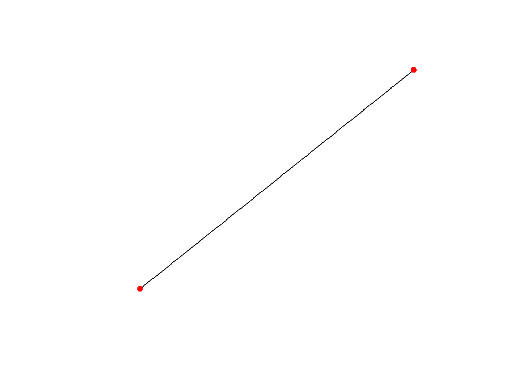

If you print these geometries

```r
point_one
```

```
## POINT (0 3)
```

```r
a_line
```

```
## LINESTRING (0 3, 5 7)
```

you see that they are represented as a text string. This is the [Well Known Text](https://en.wikipedia.org/wiki/Well-known_text_representation_of_geometry) (WKT) standard for specifying geometries. It tells us what kind of geometry the feature is and lists its x-y coordinates separated by commas.

If you want to know what geometry type your simple feature contains, try:

```r
st_geometry_type(a_line)
```

```
## [1] LINESTRING
## 18 Levels: GEOMETRY POINT LINESTRING POLYGON MULTIPOINT ... TRIANGLE
```

To show the type of the first feature in the North Carolina shapefile:

```r
st_geometry_type(north_carolina[1, ])
```

```
## [1] MULTIPOLYGON
## 18 Levels: GEOMETRY POINT LINESTRING POLYGON MULTIPOINT ... TRIANGLE
```

##### **CRS**

The final ingredient in a simple feature is its a spatial or [*coordinate reference system*](https://en.wikipedia.org/wiki/Spatial_reference_system) (CRS). A CRS provides two crucial pieces of information: (i) what rule we use to assign coordinates to points and (ii) what datum to use. It is not an exaggeration to say that **the CRS is the most important element of a simple feature**, for without a CRS, the numbers in the geometry column are just that, numbers, rather than full-blooded *spatial* coordinates.

Understanding what a coordinate assignment rule does is beyond the scope of this lab, but the datum deserves some attention. In effect, it specifies three things:

1. the origin or the point on the earth’s surface where the coordinates are `POINT (0 0)`,
2. the scale of the coordinates, for example, whether we should think of `POINT (5 7)` as being 5 *meters* east and seven *meters* north of the origin, or - worse - 5 *feet* east and 7 *feet* north, and
3. the orientation of the system, or which way is up?

As with the geometries, the standard for representing CRS is WKT, though the easiest way to identify a CRS is to use its EPSG code. To find the EPSG code for a CRS, you can visit this website: [spatialreference.org](https://spatialreference.org/).

The most widely used CRS is the World Geodetic System 84 (WGS 84, a geographic system) whose EPSG code is 4326:

```r
st_crs(4326)
```

```
## Coordinate Reference System:
##   User input: EPSG:4326
##   wkt:
## GEOGCRS["WGS 84",
##     ENSEMBLE["World Geodetic System 1984 ensemble",
##         MEMBER["World Geodetic System 1984 (Transit)"],
##         MEMBER["World Geodetic System 1984 (G730)"],
##         MEMBER["World Geodetic System 1984 (G873)"],
##         MEMBER["World Geodetic System 1984 (G1150)"],
##         MEMBER["World Geodetic System 1984 (G1674)"],
##         MEMBER["World Geodetic System 1984 (G1762)"],
##         MEMBER["World Geodetic System 1984 (G2139)"],
##         MEMBER["World Geodetic System 1984 (G2296)"],
##         ELLIPSOID["WGS 84",6378137,298.257223563,
##             LENGTHUNIT["metre",1]],
##         ENSEMBLEACCURACY[2.0]],
##     PRIMEM["Greenwich",0,
##         ANGLEUNIT["degree",0.0174532925199433]],
##     CS[ellipsoidal,2],
##         AXIS["geodetic latitude (Lat)",north,
##             ORDER[1],
##             ANGLEUNIT["degree",0.0174532925199433]],
##         AXIS["geodetic longitude (Lon)",east,
##             ORDER[2],
##             ANGLEUNIT["degree",0.0174532925199433]],
##     USAGE[
##         SCOPE["Horizontal component of 3D system."],
##         AREA["World."],
##         BBOX[-90,-180,90,180]],
##     ID["EPSG",4326]]
```

If you are familiar with the PROJ4-string syntax, you can retrieve that from a CRS with:

```r
st_crs(4326)$proj4string
```

```
## [1] "+proj=longlat +datum=WGS84 +no_defs"
```

However, current open standards specified by PROJ and GDAL discourage the use of PROJ4-string syntax in favor of WKT, so it is probably best to get use to the latter now.

##### **Bounding Box**

There’s actually one more element to a simple feature, but it is not as vital as the others and is really already implicit in the geometry. That is the bounding box. This is an object defined by the spatial extent of the data: the minimum and maximum x and y coordinates. You can retrieve the bounding box of a simple feature this way:

```r
st_bbox(north_carolina)
```

```
##      xmin      ymin      xmax      ymax
## -84.32385  33.88199 -75.45698  36.58965
```

There are myriad uses for the bounding box, though we need not dwell on them here.

# Read and Write

Reading and writing spatial data, it turns out, is quite the chore. The solution `sf` relies on is to interface with GDAL, which handles lots of different spatial data types (it’s kinda its whole purpose). Currently supported (vector) spatial data types can be found at [GDAL.org](https://gdal.org/drivers/vector/index.html). Perhaps the most common spatial data type - because ESRI is a thing - is the shapefile, which has a *.shp* file extension.

### Reading in spatial data

In `sf`, the function for reading in spatial data is `st_read`. Here is the nitty-gritty and, perhaps, needlessly verbose version first:

```r
#./data/utahcounty/utahcounty.shp

utah <- st_read(dsn = "./datafiles/utahcounty/utahcounty.shp",
                layer = "utahcounty",
                drivers = "ESRI Shapefile")
```

```
## options:        ESRI Shapefile
```

`dsn` stands for “data source name” and specifies where the data is coming from, whether a file directory, a database, or something else. `layer` is the layer in the data source to be read in. Finally, `drivers` tells GDAL what format the file is in or what structure it has, so it knows how to correctly interpret the file. All of this information is printed to the console when you execute `st_read`.

In this case, we are using a simple ESRI shapefile, so the data source and layer are basically the same thing. Furthermore, `sf` is good at guessing the driver based on the file extension, so the driver does not normally need to be specified. Hence, we could just as well have written:

```r
utah <- st_read("./datafiles/utahcounty/utahcounty.shp")
```

And here’s what this looks like. The combination of `st_geometry` and `plot` extracts only the spatial geometry (the polygons) and plots those. We’ll look more closely at plotting these and making maps later.

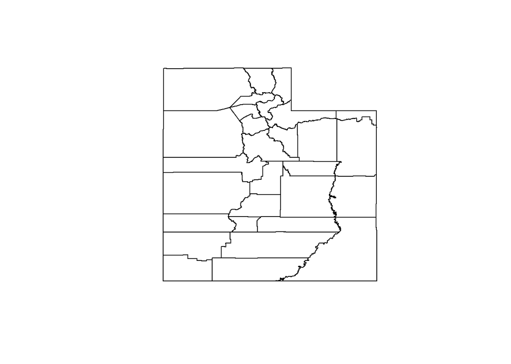

```r
plot(st_geometry(utah))
```

### Converting non-spatial data to simple features

Sometimes you have spatial data, but it is not in a spatial data format. Usually, this means you have a table or spreadsheet with columns for the x and y coordinates.

```r
wna_climate <- read.csv("./datafiles/WNAclimate.csv")

head(wna_climate)
```

```
##   WNASEQ     LONDD   LATDD ELEV totsnopt annp Jan_Tmp Jul_Tmp
## 1      1 -107.9333 50.8736  686  78.7869  326   -13.9    18.8
## 2      2 -105.2670 55.2670  369 145.3526  499   -21.3    16.8
## 3      3 -102.5086 41.7214 1163  42.6544  450    -4.2    23.3
## 4      4 -110.2606 44.2986 2362 255.1009  489   -10.9    14.1
## 5      5 -114.1500 59.2500  880 164.8924  412   -23.9    14.4
## 6      6 -120.6667 57.4500  900 141.9260  451   -17.5    13.8
```

This can be converted to a simple feature using the `st_as_sf` function like so:

```r
wna_climate <- st_as_sf(wna_climate,
                        coords = c("LONDD", "LATDD"),
                        crs = 4326)

wna_climate
```

```
## Simple feature collection with 2012 features and 6 fields
## Geometry type: POINT
## Dimension:     XY
## Bounding box:  xmin: -138 ymin: 29.8333 xmax: -100 ymax: 60
## Geodetic CRS:  WGS 84
## First 10 features:
##    WNASEQ ELEV totsnopt annp Jan_Tmp Jul_Tmp                  geometry
## 1       1  686  78.7869  326   -13.9    18.8 POINT (-107.9333 50.8736)
## 2       2  369 145.3526  499   -21.3    16.8   POINT (-105.267 55.267)
## 3       3 1163  42.6544  450    -4.2    23.3 POINT (-102.5086 41.7214)
## 4       4 2362 255.1009  489   -10.9    14.1 POINT (-110.2606 44.2986)
## 5       5  880 164.8924  412   -23.9    14.4     POINT (-114.15 59.25)
## 6       6  900 141.9260  451   -17.5    13.8   POINT (-120.6667 57.45)
## 7       7 1100 183.4187  492   -18.8    13.2 POINT (-119.7167 56.7167)
## 8       8 1480 191.5657  606   -11.0    12.8    POINT (-114.6 50.7667)
## 9       9  651 144.9015  443   -22.4    15.3 POINT (-122.1667 59.5167)
## 10     10  725 151.0778  455   -23.5    15.4    POINT (-112.1 57.7667)
```

The function just needs to know what columns the x and y coordinates are in and what CRS they are specified in. And here’s what it looks like:

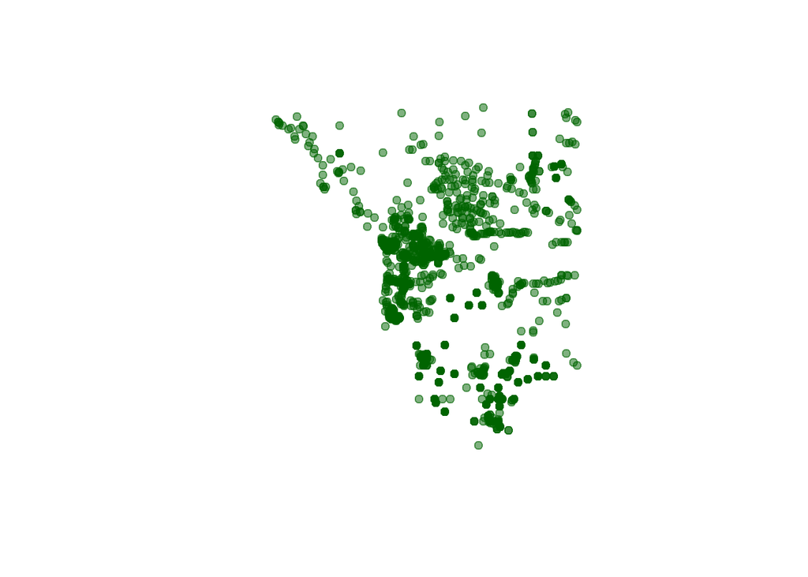

```r
plot(st_geometry(wna_climate), pch = 19, col = alpha("darkgreen", 0.5))
```

### Writing spatial data

The `sf` function for writing simple features to disk is `st_write`. It is almost an exact mirror of `st_read`, but it also requires that you specify the simple feature object in your R environment that you want to write to disk. If the layer already exists, you will need to specify `delete_layer = TRUE`.

```r
st_write(obj = wna_climate,
         dsn = "./datafiles/wnaclim.shp",
         layer = "wnaclim",
         drivers = "ESRI Shapefile")
```

or, more simply:

```r
st_write(wna_climate, dsn = "./datafiles/wnaclim.shp")
```

# CRS operations

**The cardinal rule for working with any spatial data is to make sure all of it is in the same CRS.** This ensures that any analysis which combines multiple sources is correctly comparing values at the same locations. Never ever ever ever do anything with your data until you are sure you’ve got the CRS right.

The `st_crs()` function allows you to quickly check the CRS for any object.

```r
st_crs(utah)
```

```
## Coordinate Reference System: NA
```

Which shows as missing (`NA`), as there was no prj file with this shapefile. We can set this using an EPSG code. The shapefile is in WGS84, and the EPSG code for this is 4326. There are two methods to set the CRS for a spatial object: `st_crs<-` and `st_set_crs`.

```r
utah <- st_set_crs(utah, 4326)

st_crs(utah) <- 4326
```

If we now recheck the CRS, you’ll see that it is now fully informed in WKT format:

```r
st_crs(utah)
```

```
## Coordinate Reference System:
##   User input: EPSG:4326
##   wkt:
## GEOGCRS["WGS 84",
##     ENSEMBLE["World Geodetic System 1984 ensemble",
##         MEMBER["World Geodetic System 1984 (Transit)"],
##         MEMBER["World Geodetic System 1984 (G730)"],
##         MEMBER["World Geodetic System 1984 (G873)"],
##         MEMBER["World Geodetic System 1984 (G1150)"],
##         MEMBER["World Geodetic System 1984 (G1674)"],
##         MEMBER["World Geodetic System 1984 (G1762)"],
##         MEMBER["World Geodetic System 1984 (G2139)"],
##         MEMBER["World Geodetic System 1984 (G2296)"],
##         ELLIPSOID["WGS 84",6378137,298.257223563,
##             LENGTHUNIT["metre",1]],
##         ENSEMBLEACCURACY[2.0]],
##     PRIMEM["Greenwich",0,
##         ANGLEUNIT["degree",0.0174532925199433]],
##     CS[ellipsoidal,2],
##         AXIS["geodetic latitude (Lat)",north,
##             ORDER[1],
##             ANGLEUNIT["degree",0.0174532925199433]],
##         AXIS["geodetic longitude (Lon)",east,
##             ORDER[2],
##             ANGLEUNIT["degree",0.0174532925199433]],
##     USAGE[
##         SCOPE["Horizontal component of 3D system."],
##         AREA["World."],
##         BBOX[-90,-180,90,180]],
##     ID["EPSG",4326]]
```

Note: this should only be used when the simple feature is missing a CRS and you know what it is. It is **NOT** for *re-projecting* the sf object to a new coordinate system.

### Reprojecting CRS

The `st_transform()` function allows you to project your sf object to a new CRS. This is particularly useful if you have multiple data sources with different original coordinate systems. Here, we’ll reproject the Utah country data to UTM Zone 12N (EPSG code 32612):

```r
utah <- st_transform(utah, crs = 32612)

st_crs(utah)
```

```
## Coordinate Reference System:
##   User input: EPSG:32612
##   wkt:
## PROJCRS["WGS 84 / UTM zone 12N",
##     BASEGEOGCRS["WGS 84",
##         ENSEMBLE["World Geodetic System 1984 ensemble",
##             MEMBER["World Geodetic System 1984 (Transit)"],
##             MEMBER["World Geodetic System 1984 (G730)"],
##             MEMBER["World Geodetic System 1984 (G873)"],
##             MEMBER["World Geodetic System 1984 (G1150)"],
##             MEMBER["World Geodetic System 1984 (G1674)"],
##             MEMBER["World Geodetic System 1984 (G1762)"],
##             MEMBER["World Geodetic System 1984 (G2139)"],
##             MEMBER["World Geodetic System 1984 (G2296)"],
##             ELLIPSOID["WGS 84",6378137,298.257223563,
##                 LENGTHUNIT["metre",1]],
##             ENSEMBLEACCURACY[2.0]],
##         PRIMEM["Greenwich",0,
##             ANGLEUNIT["degree",0.0174532925199433]],
##         ID["EPSG",4326]],
##     CONVERSION["UTM zone 12N",
##         METHOD["Transverse Mercator",
##             ID["EPSG",9807]],
##         PARAMETER["Latitude of natural origin",0,
##             ANGLEUNIT["degree",0.0174532925199433],
##             ID["EPSG",8801]],
##         PARAMETER["Longitude of natural origin",-111,
##             ANGLEUNIT["degree",0.0174532925199433],
##             ID["EPSG",8802]],
##         PARAMETER["Scale factor at natural origin",0.9996,
##             SCALEUNIT["unity",1],
##             ID["EPSG",8805]],
##         PARAMETER["False easting",500000,
##             LENGTHUNIT["metre",1],
##             ID["EPSG",8806]],
##         PARAMETER["False northing",0,
##             LENGTHUNIT["metre",1],
##             ID["EPSG",8807]]],
##     CS[Cartesian,2],
##         AXIS["(E)",east,
##             ORDER[1],
##             LENGTHUNIT["metre",1]],
##         AXIS["(N)",north,
##             ORDER[2],
##             LENGTHUNIT["metre",1]],
##     USAGE[
##         SCOPE["Navigation and medium accuracy spatial referencing."],
##         AREA["Between 114°W and 108°W, northern hemisphere between equator and 84°N, onshore and offshore. Canada - Alberta; Northwest Territories (NWT); Nunavut; Saskatchewan. Mexico. United States (USA)."],
##         BBOX[0,-114,84,-108]],
##     ID["EPSG",32612]]
```

As a reminder: when you read in spatial data, the first thing you should use is `st_crs` to check the CRS and `st_transform` to re-project if necessary.

You can also check the EPSG code (if specified):

```r
st_crs(utah)$epsg
```

```
## [1] 32612
```

```r
st_crs(wna_climate)$epsg
```

```
## [1] 4326
```

And you can get the name of a CRS this way:

```r
format(st_crs(utah))
```

```
## [1] "WGS 84 / UTM zone 12N"
```

# Attribute operations

The attribute part of a `sf` object is a data.frame, so you can use all the methods we have previously looked at for data manipulation in working with attributes.

```r
class(utah)
```

```
## [1] "sf"         "data.frame"
```

If you enter the name of an `sf` object, it will print the first few rows of the attribute table:

```r
utah
```

```
## Simple feature collection with 29 features and 13 fields
## Geometry type: POLYGON
## Dimension:     XY
## Bounding box:  xmin: 228583.4 ymin: 4094744 xmax: 673944.6 ymax: 4653572
## Projected CRS: WGS 84 / UTM zone 12N
## First 10 features:
##    SP_ID COUNTYNBR  ENTITYNBR ENTITYYR       NAME FIPS STATEPLANE POP_LASTCE
## 1      0        13 2010131010     2010       KANE   25      South       7125
## 2      1        14 2010141010     2010    MILLARD   27    Central      12503
## 3      2        20 2010201010     2010    SANPETE   39    Central      27822
## 4      3        04 2010041010     2010     CARBON    7    Central      21403
## 5      4        25 2010251010     2010       UTAH   49    Central     516564
## 6      5        03 2010031010     2010      CACHE    5      North     112656
## 7      6        22 2010221010     2010     SUMMIT   43      North      36324
## 8      7        27 2010271010     2010 WASHINGTON   53      South     138115
```

[output cut: 24 more lines]

### Select Columns

As this is a dataframe at heart, we can use the same functions we looked at in the previous lab to manipulate the data:

```r
# method 1 (base R)
utah2 <- utah[ , c("NAME", "FIPS", "POP_CURRES")]

# method 2 (dplyr)
library(dplyr)
utah2 <- utah %>%
  select(NAME, FIPS, POP_CURRES)

names(utah)
```

```
##  [1] "SP_ID"      "COUNTYNBR"  "ENTITYNBR"  "ENTITYYR"   "NAME"
##  [6] "FIPS"       "STATEPLANE" "POP_LASTCE" "POP_CURRES" "FIPS_STR"
## [11] "COLOR4"     "Shape_Leng" "Shape_Area" "geometry"
```

```r
names(utah2)
```

```
## [1] "NAME"       "FIPS"       "POP_CURRES" "geometry"
```

Notice this very important difference between regular data.frames and `sf` data.frames: when you subset by columns, even though you do not explicitly state that you want to keep the geometry column, it keeps that column anyway. In this sense, the geometry column is said to be “sticky”.

### Filter Rows

Subsetting the data by rows works in the same way as before. So we can carry out conditional selection of locations by using the usual comparison operators (`<, <=, ==, !=, >=, >`). For example, to select only the counties with over 50,000 people:

```r
# method 1
utah3 <- utah[utah$POP_CURRES > 50000, ]

# method 2
utah3 <- utah2 %>%
  filter(POP_CURRES > 50000)
```

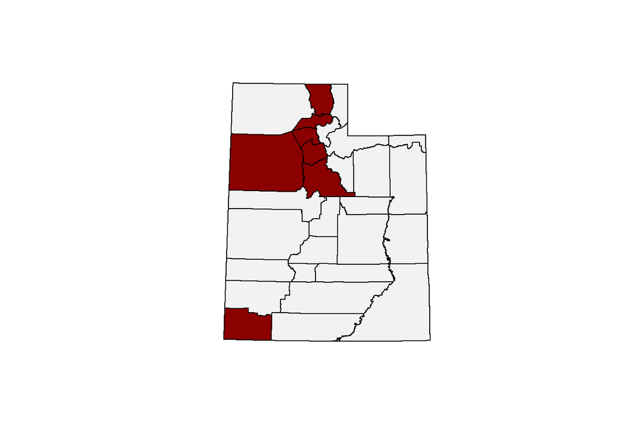

```r
plot(st_geometry(utah), col = alpha("gray", 0.2), pch = 19)

plot(st_geometry(utah3), col = "darkred", pch = 19, add = TRUE)
```

### Add Column

New variables can easily be appended to an existing `sf` object using the following notation:

```r
utah$area_km2 <- utah$Shape_Area / 1e6

# method 2
utah <- utah %>%
  mutate(area_km2 = Shape_Area / 1e6)

names(utah)
```

```
##  [1] "SP_ID"      "COUNTYNBR"  "ENTITYNBR"  "ENTITYYR"   "NAME"
##  [6] "FIPS"       "STATEPLANE" "POP_LASTCE" "POP_CURRES" "FIPS_STR"
## [11] "COLOR4"     "Shape_Leng" "Shape_Area" "geometry"   "area_km2"
```

### Extract Column

If you need to extract any variable from a `sf` object to a standard R vector, you can again use the standard notation. Note that if you use `select` to specify the columns, you need to also add `st_drop_geometry` to remove the geometry:

```r
# method 1
area_km2 <- utah$area_km2

# method 2
area_km2 <- utah %>%
  select(area_km2) %>%
  st_drop_geometry()

area_km2$area_km2[1:10]
```

```
##  [1] 10631.564 17708.675  4146.734  3844.122  5544.906  3035.355  4870.023
##  [8]  6297.925  9539.294 11661.946
```

### Get Geometry

If you need only the geometry (the set of coordinates, or vector definitions), these can be extracted as follows:

```r
geometry <- st_geometry(utah)

geometry
```

```
## Geometry set for 29 features
## Geometry type: POLYGON
## Dimension:     XY
## Bounding box:  xmin: 228583.4 ymin: 4094744 xmax: 673944.6 ymax: 4653572
## Projected CRS: WGS 84 / UTM zone 12N
## First 5 geometries:
```

```
## POLYGON ((425313.9 4154648, 425715.6 4154644, 4...
```

```
## POLYGON ((393592.1 4378949, 393813.7 4378945, 3...
```

```
## POLYGON ((448347.6 4407164, 448363.5 4407163, 4...
```

```
## POLYGON ((495617.5 4407122, 496010.1 4407117, 4...
```

```
## POLYGON ((449722.4 4491979, 449736.6 4491978, 4...
```

### Drop Geometry

In case you just want the attributes, not the geometry:

```r
attributes <- st_drop_geometry(utah)

head(attributes)
```

```
##   SP_ID COUNTYNBR  ENTITYNBR ENTITYYR    NAME FIPS STATEPLANE POP_LASTCE
## 1     0        13 2010131010     2010    KANE   25      South       7125
## 2     1        14 2010141010     2010 MILLARD   27    Central      12503
## 3     2        20 2010201010     2010 SANPETE   39    Central      27822
## 4     3        04 2010041010     2010  CARBON    7    Central      21403
## 5     4        25 2010251010     2010    UTAH   49    Central     516564
## 6     5        03 2010031010     2010   CACHE    5      North     112656
##   POP_CURRES FIPS_STR COLOR4 Shape_Leng  Shape_Area  area_km2
## 1       7125    49025      4   559368.8 10631563850 10631.564
## 2      12503    49027      3   576258.3 17708674898 17708.675
## 3      27822    49039      2   317646.9  4146734071  4146.734
## 4      21403    49007      1   333190.1  3844121594  3844.122
## 5     516564    49049      3   481098.2  5544905821  5544.906
## 6     112656    49005      2   290082.5  3035354927  3035.355
```

Note: this is actually a special sort of `data.frame` called a `tibble`. Not important to know about here, but does print slightly differently.

# Spatial operations

Spatial operations are like attribute operations, but they work with the geometry column rather than the attributes. There are loads of these functions, but will just review some of the more important ones here.

### Spatial Filter

This is probably the biggest one. Basically, you are taking one geometry and using it to filter other geometries. To demonstrate this, first we’ll make some random points in the `utah` simple feature, using `st_sample` to generate the random points:

```r
set.seed(1234)

random_pnts <- st_sample(utah, size = 500)

random_pnts <- st_as_sf(random_pnts)
```

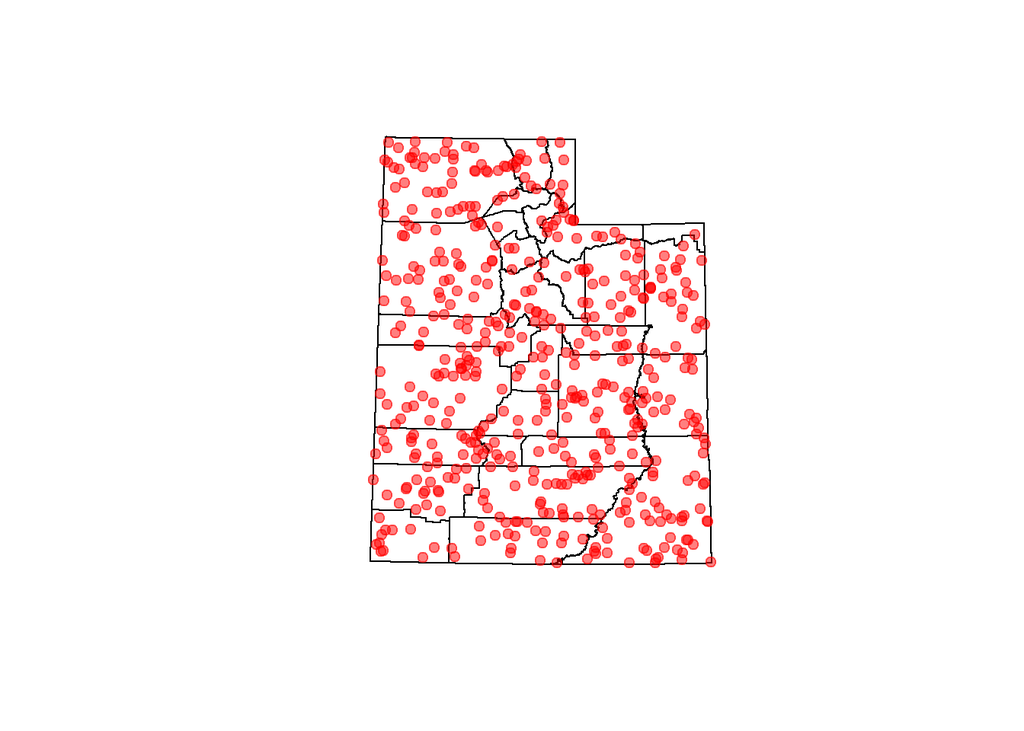

```r
plot(st_geometry(utah))

plot(st_geometry(random_pnts),
     col = alpha("red", 0.5),
     pch = 19,
     add = TRUE)
```

Now, we can use one geometry to filter out a second one. To obtain just the points in, say, Salt Lake County, we first subset the Utah `sf` object to extract only this county:

```r
slcounty <- subset(utah, NAME == "SALT LAKE")
```

Then you can filter the points using this new object, either by using the `st_filter()` function, or using the country as an index in the `[,]` notation:

```r
filtered_pnts <- st_filter(random_pnts, slcounty)

filtered_pnts <- random_pnts[slcounty, ]
```

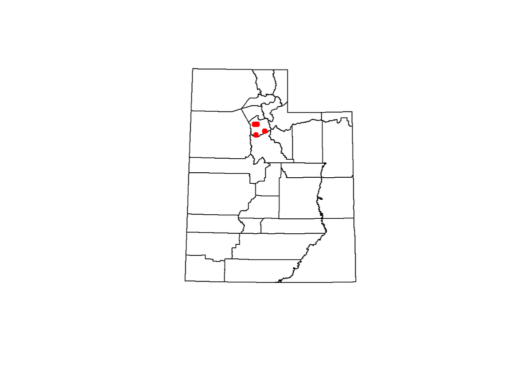

```r
plot(st_geometry(utah))

plot(st_geometry(filtered_pnts),
     col = "red",
     pch = 19,
     add = TRUE)
```

### Topological Relations

Internally, `st_filter` assumes a “topological” or spatial relationship defined by what the `sf` authors refer to as spatial predicate (`.predicate`). By default, `st_intersects` works to find the geometry of one object located within another. We can, however, specify other spatial relationships. For example, to get all the points *outside* Salt Lake:

```r
filtered_pnts <- st_filter(random_pnts, slcounty, .predicate = st_disjoint)
```

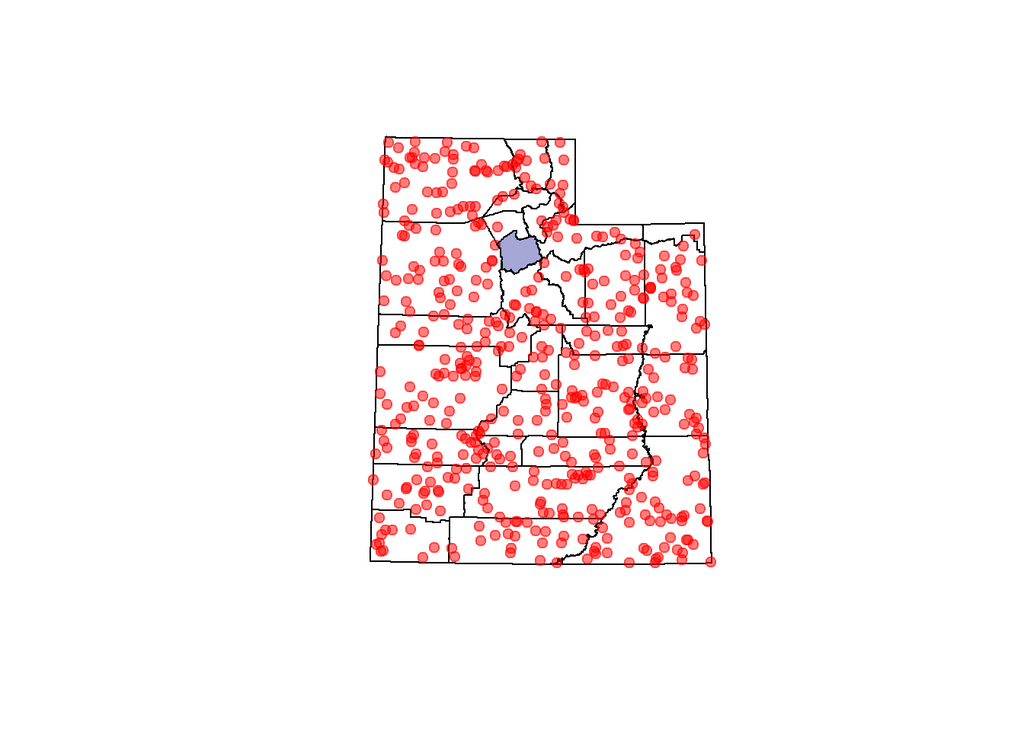

Another useful predicate is `st_is_within_distance`, which requires that you pass an additional distance (`dist`) argument to the filter. The `dist` argument is in units specified by the CRS, in this case meters.

```r
filtered_pnts <- st_filter(random_pnts,
                           slcounty,
                           .predicate = st_is_within_distance,
                           dist = 50000)
```

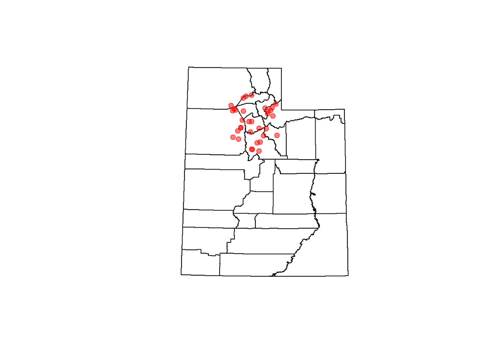

# Geometric operations

With spatial operations, the geometry is preserved (mostly). With geometric operations, the whole point is to manipulate the geometry. Again, we are just going to hit the highlights. It is worth emphasizing that **these operations will often behave differently depending on the geometry type**.

### Centroid

```r
the_heart_of_slc <- st_centroid(slcounty)
```

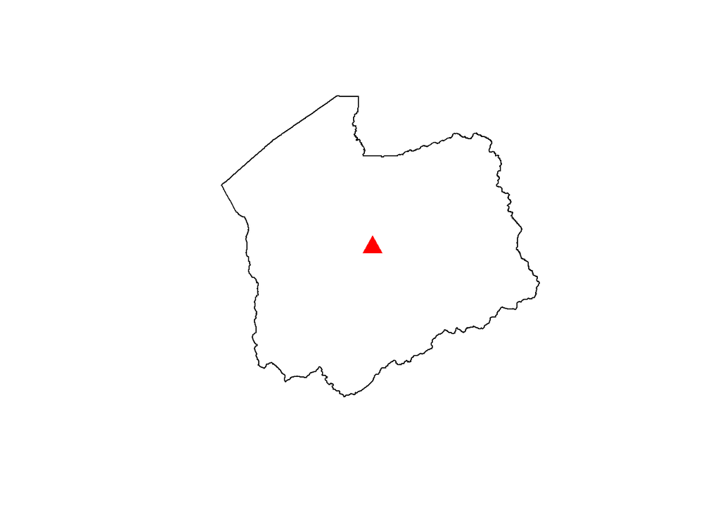

```r
plot(st_geometry(slcounty))

plot(st_geometry(the_heart_of_slc), pch = 17,
     col = "red", cex = 2, add = TRUE)
```

### Buffer

```r
the_heft_of_slc <- st_buffer(slcounty, dist = 50000)
```

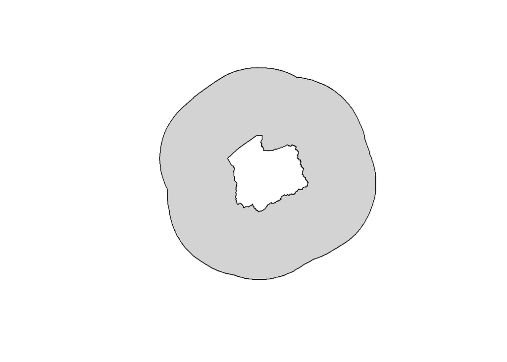

### Union

This one merges geometries and dissolves interior borders when applied to polygons.

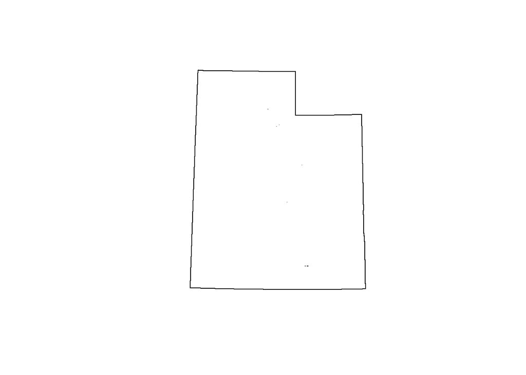

```r
utah_boundary <- st_union(utah)

plot(st_geometry(utah_boundary))
```

### Cast

To cast a geometry is to change it from one geometry type to another. For example, to convert the boundary of Salt Lake County to points (the vertices of the polygon):

```r
slc_points <- st_cast(slcounty, "POINT")
```

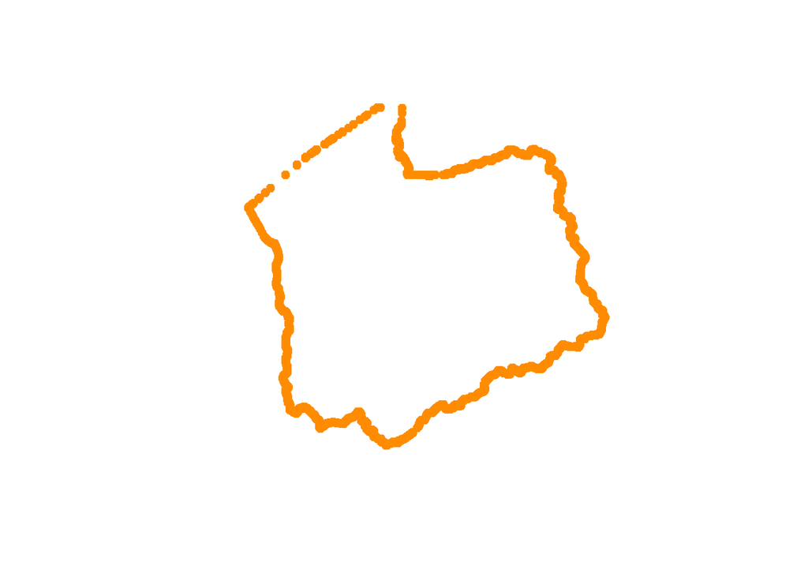

```r
plot(st_geometry(slc_points), col = "darkorange", pch = 19)
```

If we convert to a `LINESTRING` object, this acts to separate out the individual polygons:

```r
utah_lines <- st_cast(utah_boundary, "MULTILINESTRING")

utah_lines <- st_cast(utah_lines, "LINESTRING")
```

# Plotting

### `graphics`

To make simple plots of an `sf` object, you can use R’s base function `plot()`:

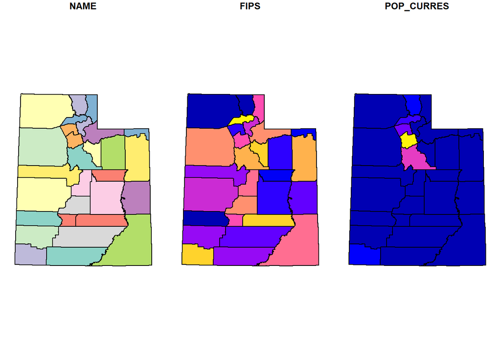

```r
plot(utah2)
```

Notice that it creates separate plots for each attribute. If you would prefer to plot the geometry itself, as we did above.

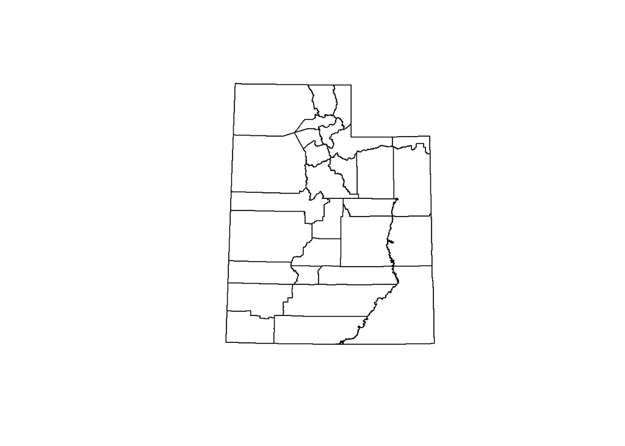

```r
plot(st_geometry(utah2))
```

### `ggplot2`

One of the easiest ways to improve on these base plots is to use **ggplot2**. This contains a a special plotting geometry, `geom_sf`, designed to work with `sf` objects. (Note that `geom_sf` refers to a **ggplot2** geometry, not a `sf` geometry. Confusing, right?)

We can now plot this by calling the `ggplot()` function and adding the `sf` object with `geom_sf`:

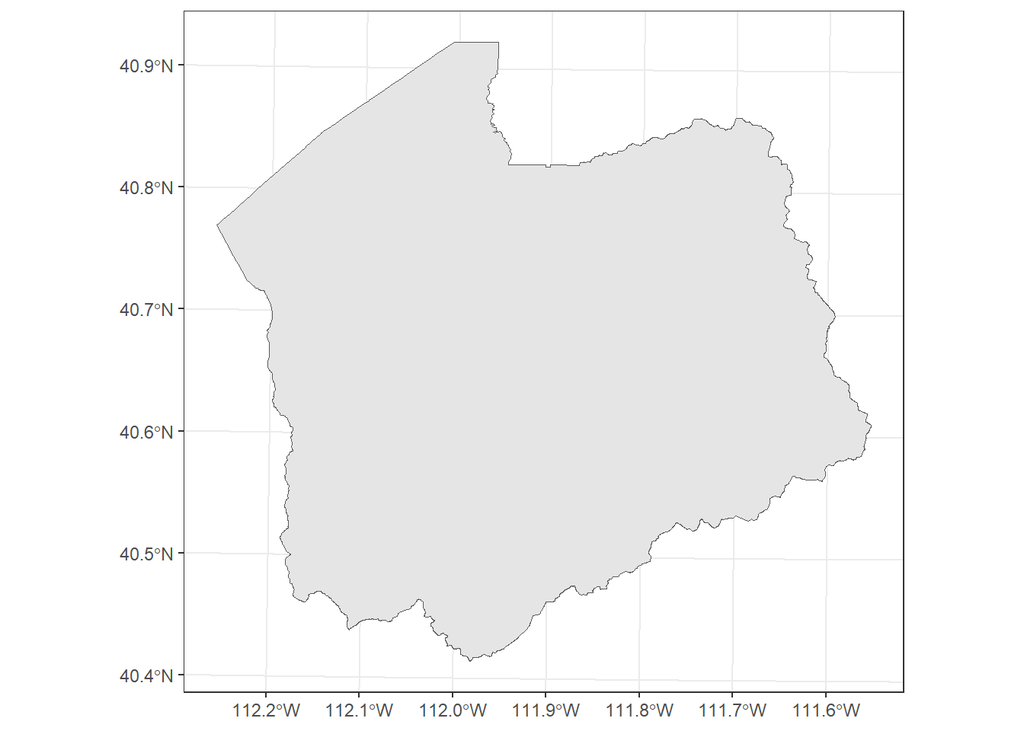

```r
ggplot() +
  geom_sf(data = slcounty) +
  theme_bw()
```

Note that even though the map is projected in UTM coordinates, the axes are set to latitude and longitude.

##### **Multiple Geometries**

Multiple layers can be added to a plot by adding additional `geom_sf` functions. Here, we read in two additional shapefiles: one containing the locations of light rail stations, and one containing the light rail tracks.

```r
lightrail <- st_read("./datafiles/LightRail_UTA/LightRail_UTA.shp")
stations <- st_read("./datafiles/LightRailStations_UTA/LightRailStations_UTA.shp")
```

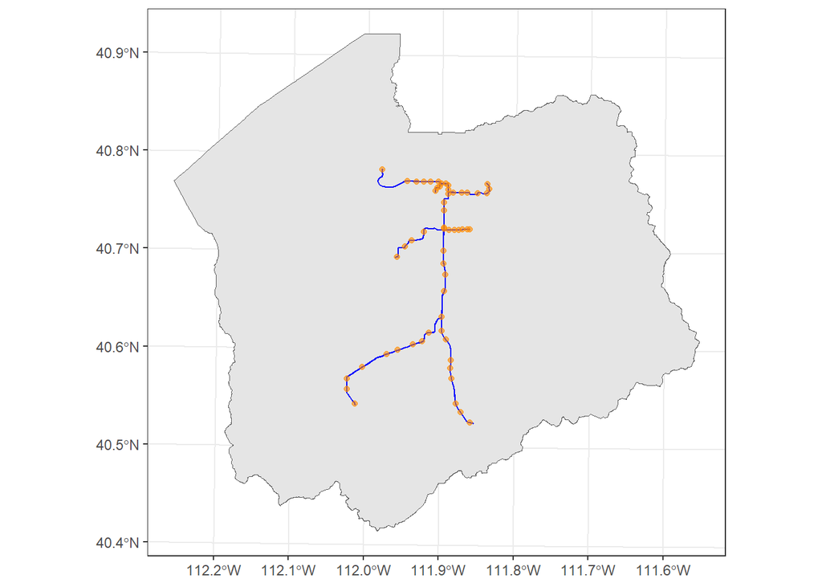

```r
ggplot() +
  geom_sf(data = slcounty) +
  geom_sf(data = lightrail, col = 'blue') +
  geom_sf(data = stations, col = 'darkorange', alpha = 0.6) +

  theme_bw()
```

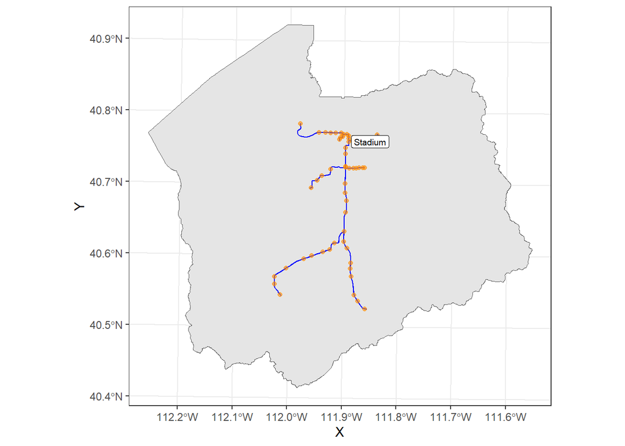

```r
stadium = stations %>%
  filter(STATIONNAM == "Stadium")
stadium = cbind(stadium, st_coordinates(stadium))
ggplot() +
  geom_sf(data = slcounty) +
  geom_sf(data = lightrail, col = 'blue') +
  geom_sf(data = stations, col = 'darkorange', alpha = 0.6) +
  geom_label(data = stadium, aes(X, Y, label = STATIONNAM), size = 2.5) +
  theme_bw()
```

##### **Plotting attributes**

We can create thematic maps by specifying the name of a variable in the `geom_sf()` function:

```r
names(utah2)
```

```
## [1] "NAME"       "FIPS"       "POP_CURRES" "geometry"
```

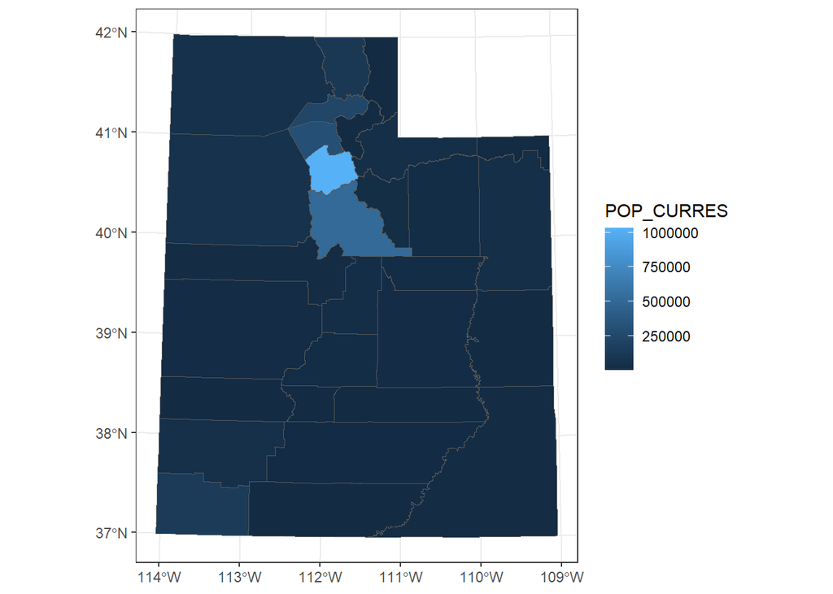

```r
ggplot() +
  geom_sf(data = utah2, aes(fill = POP_CURRES)) +
  theme_bw()
```

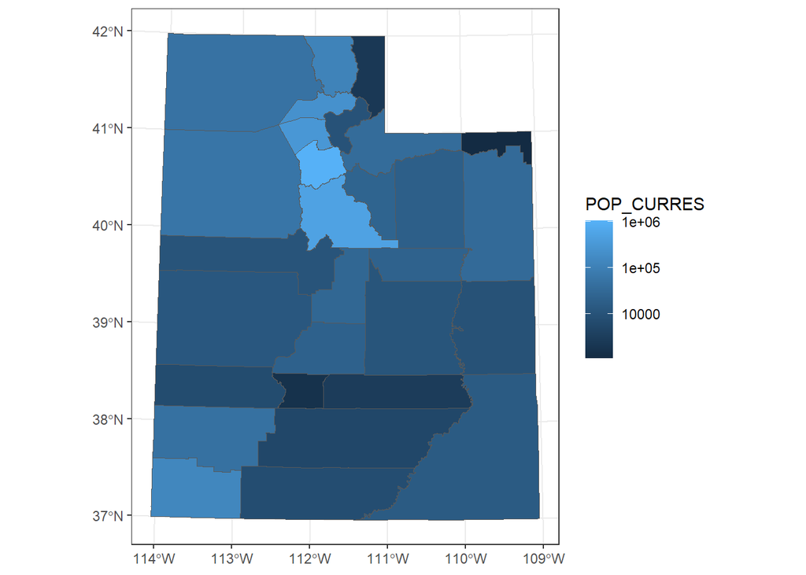

```r
my_breaks = c(0, 10000, 100000, 1000000)
ggplot() +
  geom_sf(data = utah2, aes(fill = POP_CURRES)) +
  scale_fill_continuous(trans = "log",
                        breaks = my_breaks, labels = my_breaks) +
  theme_bw()
```

##### **Manual Color Scale**

Here, we will use the `viridis` color scale, which is colorblind safe. This comes with several color palette `options`.

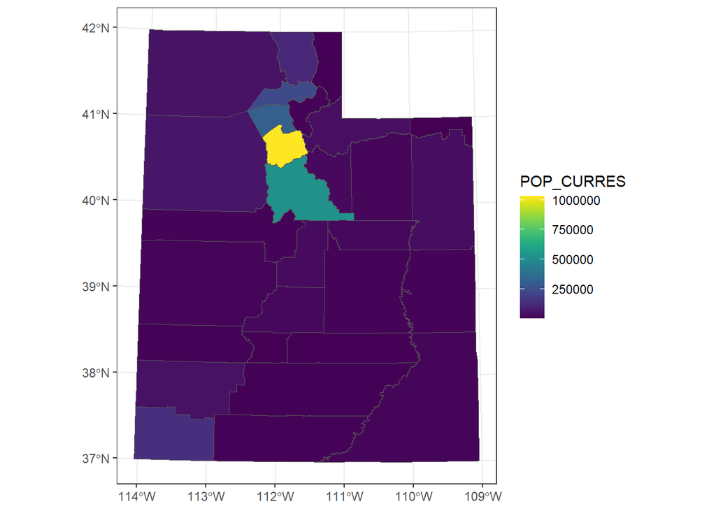

```r
ggplot() +
  geom_sf(data = utah2, aes(fill = POP_CURRES)) +
  scale_fill_viridis(option = "viridis") +
  theme_bw()
```

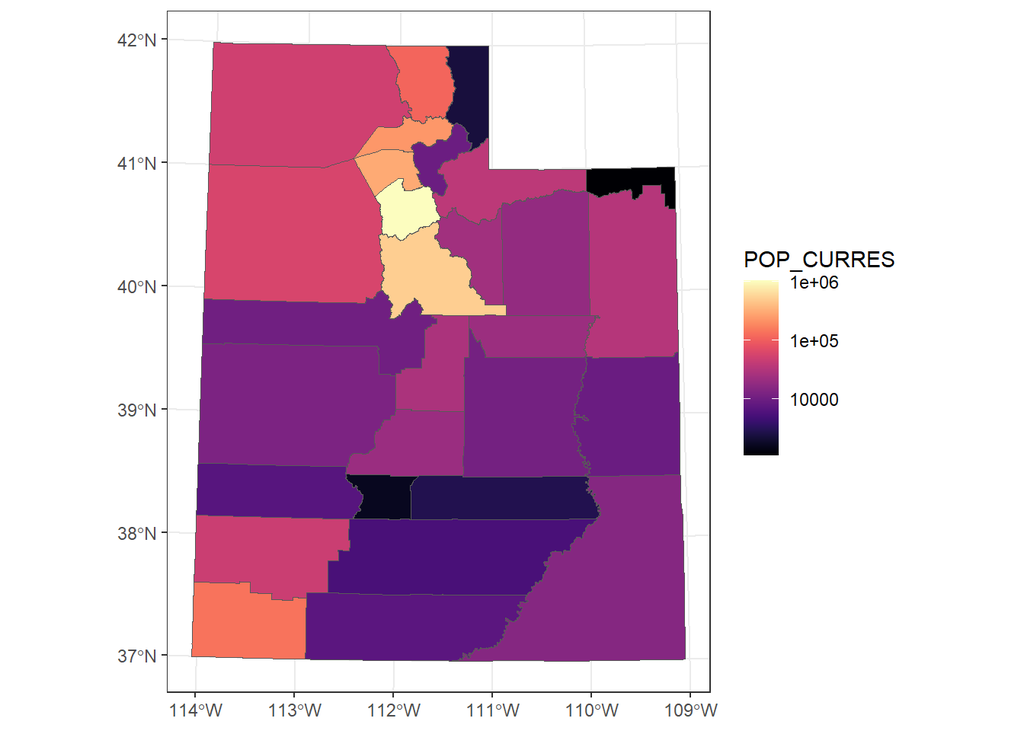

```r
ggplot() +
  geom_sf(data = utah2, aes(fill = POP_CURRES)) +
  scale_fill_viridis(option = "magma", trans = "log",
                     breaks = my_breaks, labels = my_breaks) +
  theme_bw()
```